# Линейная регрессия.

Igor

# 1. Рассмотрим встроенный в R набор данных. Датафрейм women(Этот набор данных дает средний рост и вес американских женщин в возрасте 30–39 лет)

## Подробности

Набор данных, по-видимому, был взят из исследования Американского общества актуариев по телосложению и кровяному давлению за какой-то (нам неизвестный) более ранний год.

В «Всемирном альманахе» отмечается: «Цифры представляют собой вес в обычной домашней одежде и обуви и рост с обувью».

## Источник

Мировой альманах и книга фактов, 1975.

использованная литература

Макнейл, Д.Р. (1977) Интерактивный анализ данных . Уайли.

Рост(height) измеряется в дюймах. Вес(weight) измеряется в фунтах.

```
##    height weight
## 1      58    115
## 2      59    117
## 3      60    120
## 4      61    123
## 5      62    126
## 6      63    129
## 7      64    132
## 8      65    135
## 9      66    139
## 10     67    142
## 11     68    146
## 12     69    150
## 13     70    154
## 14     71    159
## 15     72    164
```

Цифры мало о чем говорят, мало что понятнто. Переведем дюймы в сантиметры, а фунты в килограммы.

1 Фунт (pound) = 453.6 г (16 унций)

1 Дюйм = 2.54 см

```
##    height weight
## 1     147   52.2
## 2     150   53.1
## 3     152   54.4
## 4     155   55.8
## 5     157   57.2
## 6     160   58.5
## 7     163   59.9
## 8     165   61.2
## 9     168   63.1
## 10    170   64.4
## 11    173   66.2
## 12    175   68.0
## 13    178   69.9
## 14    180   72.1
## 15    183   74.4
```

Так более понятнее.

Размах роста от 147.32 до 182.88

Размах веса от 52.164 до 74.39

# 2. Попробуем на основе этих данных построить линейную регрессию предсказать вес женщин с ростом 145, 158, 185, 190 и 200 см в возрасте 30–39 лет.

## Проверим коррелируют ли между собой переменные height и weight.

```
##
##  Pearson's product-moment correlation
##
## data:  good_women$weight and good_women$height
## t = 38, df = 13, p-value = 1e-14
## alternative hypothesis: true correlation is not equal to 0
## 95 percent confidence interval:
##  0.986 0.999
## sample estimates:
##   cor
## 0.995
```

Переменные коррелируют между собой. Построим регрессионную модель.

```
##
## Call:
## lm(formula = weight ~ height, data = good_women)
##
## Residuals:
##    Min     1Q Median     3Q    Max
## -0.786 -0.514 -0.174  0.336  1.414
##
## Coefficients:
##             Estimate Std. Error t value Pr(>|t|)
## (Intercept) -39.6976     2.6930   -14.7  1.7e-09 ***
## height        0.6161     0.0163    37.9  1.1e-14 ***
## ---
## Signif. codes:  0 '***' 0.001 '**' 0.01 '*' 0.05 '.' 0.1 ' ' 1
##
## Residual standard error: 0.692 on 13 degrees of freedom
## Multiple R-squared:  0.991,  Adjusted R-squared:  0.99
## F-statistic: 1.43e+03 on 1 and 13 DF,  p-value: 1.09e-14
```

График для наглядности:

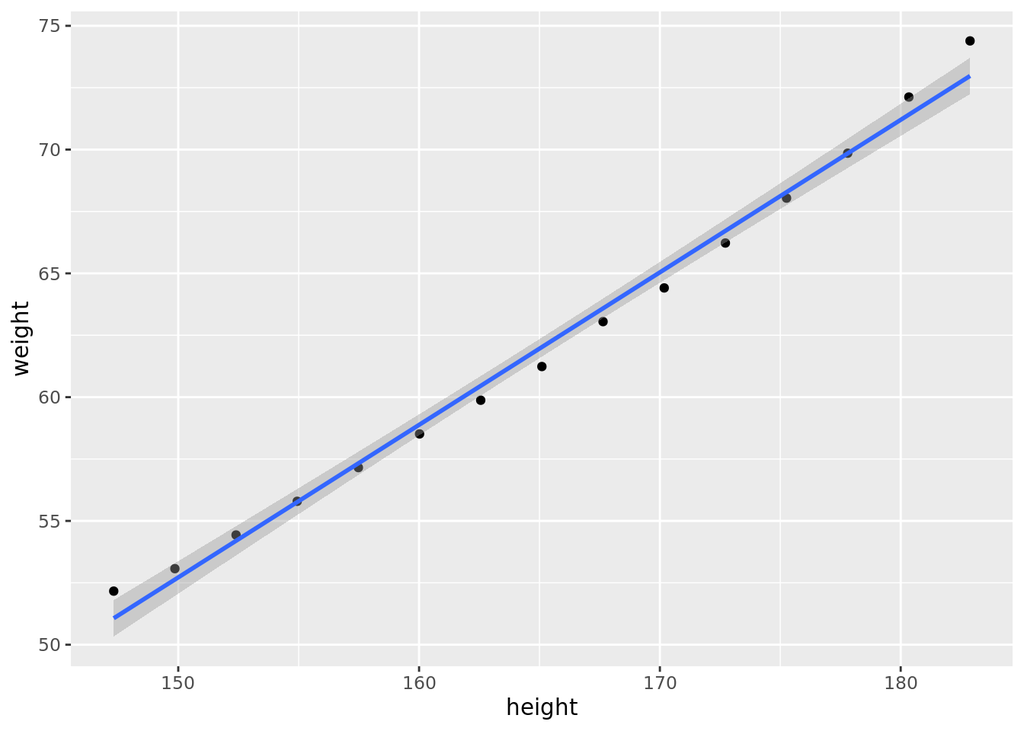

# 3. Предскажем значение переменной weight (веса) датафрейма very_good_women, на основе этих данных, на основе полученной модели линейной регресиии:

```r
very_good_women<-data.frame(height=c(145, 158, 185, 190, 200))
very_good_women
```

```
##   height
## 1    145
## 2    158
## 3    185
## 4    190
## 5    200
```

```r
very_good_women$weight<-predict(fit,very_good_women)

very_good_women
```

```
##   height weight
## 1    145   49.6
## 2    158   57.6
## 3    185   74.3
## 4    190   77.4
## 5    200   83.5
```

# 4. На основе данных women мы предсказали вес женщин с ростом 145, 158, 185, 190 и 200 см.